# Week 4 Homework

**Question 9.1** Using the same crime data set `uscrime.txt` as in Question 8.2, apply Principal Component Analysis and then create a regression model using the first few principal components. Specify your new model in terms of the original variables (not the principal components), and compare its quality to that of your solution to Question 8.2. You can use the R function `prcomp` for PCA. (Note that to first scale the data, you can include `scale. = TRUE` to scale as part of the PCA function. Don’t forget that, to make a prediction for the new city, you’ll need to unscale the coefficients (i.e., do the scaling calculation in reverse)!)

We will use the `prcomp` function in the `stats` library for PCA, and the library `factoextra` for visualization.

```r
library(stats)
library(factoextra)
```

```r
set.seed(42)
```

```r
# load data
crime <- read.delim("../week 4 data-summer/data 9.1/uscrime.txt")
head(crime)
```

|  | M | So | Ed | Po1 | Po2 | LF | M.F | Pop | NW | U1 | U2 | Wealth | Ineq | Prob | Time | Crime |
| --- | --- | --- | --- | --- | --- | --- | --- | --- | --- | --- | --- | --- | --- | --- | --- | --- |
| 1 | 15.1 | 1 | 9.1 | 5.8 | 5.6 | 0.510 | 95.0 | 33 | 30.1 | 0.108 | 4.1 | 3940 | 26.1 | 0.084602 | 26.2011 | 791 |
| 2 | 14.3 | 0 | 11.3 | 10.3 | 9.5 | 0.583 | 101.2 | 13 | 10.2 | 0.096 | 3.6 | 5570 | 19.4 | 0.029599 | 25.2999 | 1635 |
| 3 | 14.2 | 1 | 8.9 | 4.5 | 4.4 | 0.533 | 96.9 | 18 | 21.9 | 0.094 | 3.3 | 3180 | 25.0 | 0.083401 | 24.3006 | 578 |
| 4 | 13.6 | 0 | 12.1 | 14.9 | 14.1 | 0.577 | 99.4 | 157 | 8.0 | 0.102 | 3.9 | 6730 | 16.7 | 0.015801 | 29.9012 | 1969 |
| 5 | 14.1 | 0 | 12.1 | 10.9 | 10.1 | 0.591 | 98.5 | 18 | 3.0 | 0.091 | 2.0 | 5780 | 17.4 | 0.041399 | 21.2998 | 1234 |
| 6 | 12.1 | 0 | 11.0 | 11.8 | 11.5 | 0.547 | 96.4 | 25 | 4.4 | 0.084 | 2.9 | 6890 | 12.6 | 0.034201 | 20.9995 | 682 |

Using `prcomp`, apply PCA to the predictors of our `uscrime.txt` dataset.

```r
# apply pca
crime_pca <- prcomp(crime[,1:15], center=T, scale = T)
crime_pca
```

```
Standard deviations (1, .., p=15):
 [1] 2.45335539 1.67387187 1.41596057 1.07805742 0.97892746 0.74377006
 [7] 0.56729065 0.55443780 0.48492813 0.44708045 0.41914843 0.35803646
[13] 0.26332811 0.24180109 0.06792764

Rotation (n x k) = (15 x 15):
               PC1         PC2           PC3         PC4         PC5
M      -0.30371194  0.06280357  0.1724199946 -0.02035537 -0.35832737
So     -0.33088129 -0.15837219  0.0155433104  0.29247181 -0.12061130
Ed      0.33962148  0.21461152  0.0677396249  0.07974375 -0.02442839
Po1     0.30863412 -0.26981761  0.0506458161  0.33325059 -0.23527680
Po2     0.31099285 -0.26396300  0.0530651173  0.35192809 -0.20473383
LF      0.17617757  0.31943042  0.2715301768 -0.14326529 -0.39407588
M.F     0.11638221  0.39434428 -0.2031621598  0.01048029 -0.57877443
Pop     0.11307836 -0.46723456  0.0770210971 -0.03210513 -0.08317034
NW     -0.29358647 -0.22801119  0.0788156621  0.23925971 -0.36079387
U1      0.04050137  0.00807439 -0.6590290980 -0.18279096 -0.13136873
U2      0.01812228 -0.27971336 -0.5785006293 -0.06889312 -0.13499487
Wealth  0.37970331 -0.07718862  0.0100647664  0.11781752  0.01167683
Ineq   -0.36579778 -0.02752240 -0.0002944563 -0.08066612 -0.21672823
Prob   -0.25888661  0.15831708 -0.1176726436  0.49303389  0.16562829
Time   -0.02062867 -0.38014836  0.2235664632 -0.54059002 -0.14764767
                PC6         PC7         PC8         PC9        PC10
M      -0.449132706 -0.15707378 -0.55367691  0.15474793 -0.01443093
So     -0.100500743  0.19649727  0.22734157 -0.65599872  0.06141452
Ed     -0.008571367 -0.23943629 -0.14644678 -0.44326978  0.51887452
Po1    -0.095776709  0.08011735  0.04613156  0.19425472 -0.14320978
Po2    -0.119524780  0.09518288  0.03168720  0.19512072 -0.05929780
LF      0.504234275 -0.15931612  0.25513777  0.14393498  0.03077073
M.F    -0.074501901  0.15548197 -0.05507254 -0.24378252 -0.35323357
Pop     0.547098563  0.09046187 -0.59078221 -0.20244830 -0.03970718
NW      0.051219538 -0.31154195  0.20432828  0.18984178  0.49201966
U1      0.017385981 -0.17354115 -0.20206312  0.02069349  0.22765278
U2      0.048155286 -0.07526787  0.24369650  0.05576010 -0.04750100
Wealth -0.154683104 -0.14859424  0.08630649 -0.23196695 -0.11219383
Ineq    0.272027031  0.37483032  0.07184018 -0.02494384 -0.01390576
Prob    0.283535996 -0.56159383 -0.08598908 -0.05306898 -0.42530006
Time   -0.148203050 -0.44199877  0.19507812 -0.23551363 -0.29264326
              PC11        PC12        PC13        PC14          PC15
M       0.39446657  0.16580189  0.05142365  0.04901705 -0.0051398012
So      0.23397868 -0.05753357  0.29368483 -0.29364512 -0.0084369230
Ed     -0.11821954  0.47786536 -0.19441949  0.03964277  0.0280052040
Po1    -0.13042001  0.22611207  0.18592255 -0.09490151  0.6894155129
Po2    -0.13885912  0.19088461  0.13454940 -0.08259642 -0.7200270100
LF      0.38532827  0.02705134  0.27742957 -0.15385625 -0.0336823193
M.F    -0.28029732 -0.23925913 -0.31624667 -0.04125321 -0.0097922075
Pop     0.05849643 -0.18350385 -0.12651689 -0.05326383 -0.0001496323
NW     -0.20695666 -0.36671707 -0.22901695  0.13227774  0.0370783671
U1     -0.17857891 -0.09314897  0.59039450 -0.02335942 -0.0111359325
U2      0.47021842  0.28440496 -0.43292853 -0.03985736 -0.0073618948
Wealth  0.31955631 -0.32172821  0.14077972  0.70031840  0.0025685109
Ineq   -0.18278697  0.43762828  0.12181090  0.59279037 -0.0177570357
Prob   -0.08978385  0.15567100  0.03547596  0.04761011 -0.0293376260
Time   -0.26363121  0.13536989  0.05738113 -0.04488401 -0.0376754405
```

We can visualize the eigenvalues in a scree plot against the number of principal components used. This plot shows us the percentage of variances explained by each principal component.

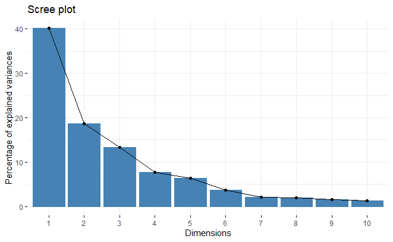

```r
# scree plot
fviz_eig(crime_pca)
```

From the scree plot, we can see that after 4-5 principal components, the increase in variance explained becomes relatively small around 5 components. There is less and less of an advantage in using more components after the 5th component. We will proceed to build linear regression model with these 5 components.

```r
# create new crime dataframe with first 5 components
top5_components <- crime_pca$x[,1:5] # get first 5 cols of PCA components
PCAcrime <- as.data.frame(cbind(top5_components, crime[,16])) # create df with response column
PCAcrime
```

| PC1 | PC2 | PC3 | PC4 | PC5 | V6 |
| --- | --- | --- | --- | --- | --- |
| -4.1992835 | -1.09383120 | -1.11907395 | 0.67178115 | 0.055283376 | 791 |
| 1.1726630 | 0.67701360 | -0.05244634 | -0.08350709 | -1.173199821 | 1635 |
| -4.1737248 | 0.27677501 | -0.37107658 | 0.37793995 | 0.541345246 | 578 |
| 3.8349617 | -2.57690596 | 0.22793998 | 0.38262331 | -1.644746496 | 1969 |
| 1.8392999 | 1.33098564 | 1.27882805 | 0.71814305 | 0.041590320 | 1234 |
| 2.9072336 | -0.33054213 | 0.53288181 | 1.22140635 | 1.374360960 | 682 |
| 0.2457752 | -0.07362562 | -0.90742064 | 1.13685873 | 0.718644387 | 963 |
| -0.1301330 | -1.35985577 | 0.59753132 | 1.44045387 | -0.222781388 | 1555 |
| -3.6103169 | -0.68621008 | 1.28372246 | 0.55171150 | -0.324292990 | 856 |
| 1.1672376 | 3.03207033 | 0.37984502 | -0.28887026 | -0.646056610 | 705 |

[output cut: 37 more lines]

```r
# build pca linear regression model
model1 <- lm(V6~., data=PCAcrime)
summary(model1)
```

```
Call:
lm(formula = V6 ~ ., data = PCAcrime)

Residuals:
    Min      1Q  Median      3Q     Max
-420.79 -185.01   12.21  146.24  447.86

Coefficients:
            Estimate Std. Error t value Pr(>|t|)
(Intercept)   905.09      35.59  25.428  < 2e-16 ***
PC1            65.22      14.67   4.447 6.51e-05 ***
PC2           -70.08      21.49  -3.261  0.00224 **
PC3            25.19      25.41   0.992  0.32725
PC4            69.45      33.37   2.081  0.04374 *
PC5          -229.04      36.75  -6.232 2.02e-07 ***
---
Signif. codes:  0 ‘***’ 0.001 ‘**’ 0.01 ‘*’ 0.05 ‘.’ 0.1 ‘ ’ 1

Residual standard error: 244 on 41 degrees of freedom
Multiple R-squared:  0.6452,    Adjusted R-squared:  0.6019
F-statistic: 14.91 on 5 and 41 DF,  p-value: 2.446e-08
```

Now we have to unscale our coefficients, expressing our principal components in terms of the original variables.

Let’s see our PCA coefficients and intercept first:

```r
# lr coefficients using pca components
scaled_coefficients <- model1$coefficients[2:6]
scaled_coefficients
```

```
       PC1        PC2        PC3        PC4        PC5
  65.21593  -70.08312   25.19408   69.44603 -229.04282
```

```r
# lr intercept using pca components
scaled_intercept <- model1$coefficients[1]
scaled_intercept
```

```
(Intercept)
   905.0851
```

We also need to obtain the eigenvectors for each variable.

```r
# implied regression coefficients for x_j from pca
eigenvectors <- crime_pca$rotation[,1:5]%*%scaled_coefficients
eigenvectors
```

```
             [,1]
M       60.794349
So      37.848243
Ed      19.947757
Po1    117.344887
Po2    111.450787
LF      76.254902
M.F    108.126558
Pop     58.880237
NW      98.071790
U1       2.866783
U2      32.345508
Wealth  35.933362
Ineq    22.103697
Prob   -34.640264
Time    27.205022
```

Then, we can transform our scaled coefficients to obtain the unscaled coefficients and intercept.

```r
# unscaled coefficients
unscaled_coefficients <- eigenvectors/crime_pca$scale
unscaled_coefficients
```

```
                [,1]
M       4.837374e+01
So      7.901922e+01
Ed      1.783120e+01
Po1     3.948484e+01
Po2     3.985892e+01
LF      1.886946e+03
M.F     3.669366e+01
Pop     1.546583e+00
NW      9.537384e+00
U1      1.590115e+02
U2      3.829933e+01
Wealth  3.724014e-02
Ineq    5.540321e+00
Prob   -1.523521e+03
Time    3.838779e+00
```

```r
# unscaled intercept
unscaled_intercept <- scaled_intercept - sum(eigenvectors
                                             *crime_pca$center
                                             /crime_pca$scale)
unscaled_intercept
```

```
(Intercept)
  -5933.837
```

Next, let’s compare our PCA model to our base linear regression model from 8.2.

As a refresher, here is the model and the metrics from 8.2:

```r
# build base linear regression model
model2 <- lm(Crime~., data=crime)
model2
```

```
Call:
lm(formula = Crime ~ ., data = crime)

Coefficients:
(Intercept)            M           So           Ed          Po1
 -5.984e+03    8.783e+01   -3.803e+00    1.883e+02    1.928e+02
        Po2           LF          M.F          Pop           NW
 -1.094e+02   -6.638e+02    1.741e+01   -7.330e-01    4.204e+00
         U1           U2       Wealth         Ineq         Prob
 -5.827e+03    1.678e+02    9.617e-02    7.067e+01   -4.855e+03
       Time
 -3.479e+00
```

```r
# r-squared of base linear regression model
print(sprintf("base lm r-squared: %0.3f", summary(model2)$r.squared))
```

```
[1] "base lm r-squared: 0.803"
```

```r
# rmse of base linear regression model
print(sprintf("base lm rmse: %0.3f", sigma(model2)))
```

```
[1] "base lm rmse: 209.064"
```

And the model and metrics of the PCA model for this week.

```r
# unscaled pca linear regression model
y_pred <- unscaled_intercept + as.matrix(crime[,1:15])%*%unscaled_coefficients

# rsquared of pca linear regression model
rss <- sum((y_pred-crime[,16])^2)
tss <- sum((crime[,16]-mean(crime[,16]))^2)
rsquared <- 1-rss/tss
print(sprintf("pca lm r-squared: %0.3f", rsquared))
```

```
[1] "pca lm r-squared: 0.645"
```

```r
# rmse of pca linear regression model
rmse <- sqrt(mean((crime[,16]-y_pred)^2))
print(sprintf("pca lm rmse: %0.3f", rmse))
```

```
[1] "pca lm rmse: 227.913"
```

Using our PCA model to make a prediction on the sample data (given in 8.2):

```r
# create dataframe from sample input from 8.2
sample <- data.frame(M = 14.0,
                     So = 0,
                     Ed = 10.0,
                     Po1 = 12.0,
                     Po2 = 15.5,
                     LF = 0.640,
                     M.F = 94.0,
                     Pop = 150,
                     NW = 1.1,
                     U1 = 0.120,
                     U2 = 3.6,
                     Wealth = 3200,
                     Ineq = 20.1,
                     Prob = 0.04,
                     Time = 39.0)
```

```r
# make prediction with pca model
pred_pca <- unscaled_intercept + as.matrix(sample)%*%unscaled_coefficients
pred_pca
```

```
         [,1]
[1,] 1388.926
```

We can see that comparatively, the PCA linear model has a lower $R^2$ value than the base model (PCA: 0.645, Base: 0.803), and a higher RMSE compared to the base model (PCA: 227.913, Base: 209.064). However, remember that the base model was extremely over-fitted on the training data and resulted in a highly inaccurate prediction of 155. Then we removed predictors that we deemed insignificant and created a second model that ended up with a prediction of 1304. Our PCA model is more in line with this latter model with a prediction of 1388. Thus although our PCA model explains less of the data (lower $R^2$) and has a higher error (higher RMSE) compared to the base model, it is less over-fitted and generates a more accurate prediction.

**Question 10.1 (a)** Using the same crime data set uscrime.txt as in Questions 8.2 and 9.1, find the best model you can using (a) a regression tree model, and (b) a random forest model. In R, you can use the `tree` package or the `rpart` package, and the `randomForest` package. For each model, describe one or two qualitative takeaways you get from analyzing the results (i.e., don’t just stop when you have a good model, but interpret it too).

We are using the same dataset as the previous question so no need to re-import it.

```r
# load packages
library(rpart)
library(randomForest)
# review the crime dataset
head(crime)
```

|  | M | So | Ed | Po1 | Po2 | LF | M.F | Pop | NW | U1 | U2 | Wealth | Ineq | Prob | Time | Crime |
| --- | --- | --- | --- | --- | --- | --- | --- | --- | --- | --- | --- | --- | --- | --- | --- | --- |
| 1 | 15.1 | 1 | 9.1 | 5.8 | 5.6 | 0.510 | 95.0 | 33 | 30.1 | 0.108 | 4.1 | 3940 | 26.1 | 0.084602 | 26.2011 | 791 |
| 2 | 14.3 | 0 | 11.3 | 10.3 | 9.5 | 0.583 | 101.2 | 13 | 10.2 | 0.096 | 3.6 | 5570 | 19.4 | 0.029599 | 25.2999 | 1635 |
| 3 | 14.2 | 1 | 8.9 | 4.5 | 4.4 | 0.533 | 96.9 | 18 | 21.9 | 0.094 | 3.3 | 3180 | 25.0 | 0.083401 | 24.3006 | 578 |
| 4 | 13.6 | 0 | 12.1 | 14.9 | 14.1 | 0.577 | 99.4 | 157 | 8.0 | 0.102 | 3.9 | 6730 | 16.7 | 0.015801 | 29.9012 | 1969 |
| 5 | 14.1 | 0 | 12.1 | 10.9 | 10.1 | 0.591 | 98.5 | 18 | 3.0 | 0.091 | 2.0 | 5780 | 17.4 | 0.041399 | 21.2998 | 1234 |
| 6 | 12.1 | 0 | 11.0 | 11.8 | 11.5 | 0.547 | 96.4 | 25 | 4.4 | 0.084 | 2.9 | 6890 | 12.6 | 0.034201 | 20.9995 | 682 |

```r
set.seed(42)

# build regression tree
tree_model <- rpart(Crime~., data=crime)
summary(tree_model)
```

```
Call:
rpart(formula = Crime ~ ., data = crime)
  n= 47

          CP nsplit rel error   xerror      xstd
1 0.36296293      0 1.0000000 1.044786 0.2605960
2 0.14814320      1 0.6370371 0.911051 0.1945477
3 0.05173165      2 0.4888939 1.012676 0.2303736
4 0.01000000      3 0.4371622 1.012402 0.2315240

Variable importance
   Po1    Po2 Wealth   Ineq   Prob      M     NW    Pop   Time     Ed     LF
    17     17     11     11     10     10      9      5      4      4      1
    So
     1

Node number 1: 47 observations,    complexity param=0.3629629
  mean=905.0851, MSE=146402.7
  left son=2 (23 obs) right son=3 (24 obs)
  Primary splits:
      Po1    < 7.65      to the left,  improve=0.3629629, (0 missing)
      Po2    < 7.2       to the left,  improve=0.3629629, (0 missing)
      Prob   < 0.0418485 to the right, improve=0.3217700, (0 missing)
      NW     < 7.65      to the left,  improve=0.2356621, (0 missing)
      Wealth < 6240      to the left,  improve=0.2002403, (0 missing)
  Surrogate splits:
      Po2    < 7.2       to the left,  agree=1.000, adj=1.000, (0 split)
      Wealth < 5330      to the left,  agree=0.830, adj=0.652, (0 split)
      Prob   < 0.043598  to the right, agree=0.809, adj=0.609, (0 split)
      M      < 13.25     to the right, agree=0.745, adj=0.478, (0 split)
      Ineq   < 17.15     to the right, agree=0.745, adj=0.478, (0 split)

Node number 2: 23 observations,    complexity param=0.05173165
  mean=669.6087, MSE=33880.15
  left son=4 (12 obs) right son=5 (11 obs)
  Primary splits:
      Pop < 22.5      to the left,  improve=0.4568043, (0 missing)
      M   < 14.5      to the left,  improve=0.3931567, (0 missing)
      NW  < 5.4       to the left,  improve=0.3184074, (0 missing)
      Po1 < 5.75      to the left,  improve=0.2310098, (0 missing)
```

[output cut: 20 more lines]

```
      Time < 21.9001   to the left,  agree=0.750, adj=0.4, (0 split)
      Pop  < 30        to the left,  agree=0.708, adj=0.3, (0 split)
      LF   < 0.5885    to the right, agree=0.667, adj=0.2, (0 split)

Node number 4: 12 observations
  mean=550.5, MSE=20317.58

Node number 5: 11 observations
  mean=799.5455, MSE=16315.52

Node number 6: 10 observations
  mean=886.9, MSE=55757.49

Node number 7: 14 observations
  mean=1304.929, MSE=144801.8
```

[figure not shown]

```r
plot(tree_model)
text(tree_model)
```

```r
tree_model$variable.importance
```

```
      Po1       Po2    Wealth      Ineq      Prob         M        NW
2497521.7 2497521.7 1628818.5 1602212.0 1520230.6 1388627.8 1245883.8
      Pop      Time        Ed        LF        So
 661770.6  601906.0  569545.9  203872.5  161800.8
```

```r
ypred.tree <- predict(tree_model)
RSS <- sum((ypred.tree-crime$Crime)^2) # the residual sum of squares
TSS <- sum((mean(crime$Crime)-crime$Crime)^2)#the total sum of squares
print(sprintf("R-Squared = %0.3f",
              R.squared.tree<-1-(RSS/TSS)))
```

```
[1] "R-Squared = 0.563"
```

**Question 10.1 (b)**

For part (b), build a random forest model

```r
set.seed(42)

# build random forest
rf_model <- randomForest(Crime~., data=crime, keep.forest=T, importance=T)
rf_model
```

```
Call:
 randomForest(formula = Crime ~ ., data = crime, keep.forest = T,      importance = T)
               Type of random forest: regression
                     Number of trees: 500
No. of variables tried at each split: 5

          Mean of squared residuals: 87379.48
                    % Var explained: 40.32
```

```r
# importance of each predictor
randomForest::importance(rf_model)
```

```
           %IncMSE IncNodePurity
M       3.00690191     225937.17
So     -0.01356852      22096.35
Ed      1.80268010     204621.10
Po1    10.83366782    1164661.94
Po2    10.47727967    1116121.11
LF      2.15720728     258079.02
M.F     1.46736557     315056.16
Pop    -0.83229685     323553.45
NW      9.10386424     530706.09
U1     -1.22865150     135559.27
U2      1.15212612     196488.67
Wealth  4.60644846     726978.33
Ineq    1.34905118     214692.60
Prob    8.48888959     882981.35
Time    0.93682829     186298.58
```

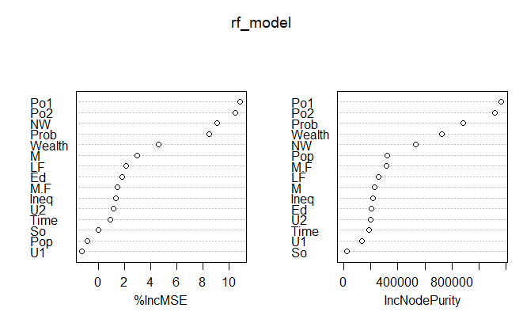

```r
varImpPlot(rf_model) #plot of importance predictors
```

```r
ypred.RF <- predict(rf_model)
RSS_rf <- sum((ypred.RF-crime$Crime)^2) # the residual sum of squares
TSS_rf <- sum((mean(crime$Crime)-crime$Crime)^2)#the total sum of squares
print(sprintf("R-Squared of Random Forest Model = %0.3f",
              R.squared.RF <- 1-(RSS_rf/TSS_rf)))
```

```
[1] "R-Squared of Random Forest Model = 0.403"
```

- Overall R-Squared = 0.403 which is very reasonable (all data points & all factors). The introduction of Randomness to the Random Forest model really helped in reducing over-fitting

**Question 10.2** Describe a situation or problem from your job, everyday life, current events, etc., for which a logistic regression model would be appropriate. List some (up to 5) predictors that you might use.

Logistic regression models can be used in identifying potential bank customers that will default on loans. Some potential predictors might include:

- Credit score
- Monthly income
- Loan amount
- Age of customer

**Question 10.3.1** Using the GermanCredit data set germancredit.txt from http://archive.ics.uci.edu/ml/machine-learning-databases/statlog/german / (description at http://archive.ics.uci.edu/ml/datasets/Statlog+%28German+Credit+Data%29 ), use logistic regression to find a good predictive model for whether credit applicants are good credit risks or not. Show your model (factors used and their coefficients), the software output, and the quality of fit. You can use the `glm` function in R. To get a logistic regression (logit) model on data where the response is either zero or one, use `family=binomial(link=”logit”)` in your `glm` function call.

```r
library(caret)
```

```r
# load data
german <- read.table("../week 4 data-summer/data 10.3/germancredit.txt", sep=' ')
head(german)
```

|  | V1 | V2 | V3 | V4 | V5 | V6 | V7 | V8 | V9 | V10 | V11 | V12 | V13 | V14 | V15 | V16 | V17 | V18 | V19 | V20 | V21 |
| --- | --- | --- | --- | --- | --- | --- | --- | --- | --- | --- | --- | --- | --- | --- | --- | --- | --- | --- | --- | --- | --- |
| 1 | A11 | 6 | A34 | A43 | 1169 | A65 | A75 | 4 | A93 | A101 | 4 | A121 | 67 | A143 | A152 | 2 | A173 | 1 | A192 | A201 | 1 |
| 2 | A12 | 48 | A32 | A43 | 5951 | A61 | A73 | 2 | A92 | A101 | 2 | A121 | 22 | A143 | A152 | 1 | A173 | 1 | A191 | A201 | 2 |
| 3 | A14 | 12 | A34 | A46 | 2096 | A61 | A74 | 2 | A93 | A101 | 3 | A121 | 49 | A143 | A152 | 1 | A172 | 2 | A191 | A201 | 1 |
| 4 | A11 | 42 | A32 | A42 | 7882 | A61 | A74 | 2 | A93 | A103 | 4 | A122 | 45 | A143 | A153 | 1 | A173 | 2 | A191 | A201 | 1 |
| 5 | A11 | 24 | A33 | A40 | 4870 | A61 | A73 | 3 | A93 | A101 | 4 | A124 | 53 | A143 | A153 | 2 | A173 | 2 | A191 | A201 | 2 |
| 6 | A14 | 36 | A32 | A46 | 9055 | A65 | A73 | 2 | A93 | A101 | 4 | A124 | 35 | A143 | A153 | 1 | A172 | 2 | A192 | A201 | 1 |

```r
# update response column
german$V21[german$V21==1]<-0
german$V21[german$V21==2]<-1
```

```r
# train test split
rrow <- sample(1:nrow(german), as.integer(0.7*nrow(german), replace=F))
train <- german[rrow,]
test <- german[-rrow,]
```

```r
# build model
set.seed(42)

logreg_model <- glm(V21~., family=binomial(link="logit"), data=train)
summary(logreg_model)
```

```
Call:
glm(formula = V21 ~ ., family = binomial(link = "logit"), data = train)

Coefficients:
              Estimate Std. Error z value Pr(>|z|)
(Intercept)  3.128e-01  1.287e+00   0.243 0.807990
V1A12       -1.707e-01  2.695e-01  -0.633 0.526520
V1A13       -5.591e-01  4.212e-01  -1.328 0.184316
V1A14       -1.490e+00  2.777e-01  -5.365 8.07e-08 ***
V2           2.641e-02  1.135e-02   2.327 0.019971 *
V3A31       -1.233e-01  6.469e-01  -0.191 0.848898
V3A32       -6.221e-01  5.150e-01  -1.208 0.227040
V3A33       -7.872e-01  5.508e-01  -1.429 0.152951
V3A34       -1.355e+00  4.992e-01  -2.713 0.006664 **
V4A41       -1.617e+00  4.654e-01  -3.475 0.000511 ***
V4A410      -1.164e+00  9.721e-01  -1.198 0.231062
V4A42       -6.748e-01  3.106e-01  -2.172 0.029829 *
V4A43       -7.879e-01  2.993e-01  -2.633 0.008473 **
V4A44        6.798e-01  9.094e-01   0.748 0.454705
V4A45       -2.548e-01  7.063e-01  -0.361 0.718267
V4A46       -2.582e-01  4.585e-01  -0.563 0.573323
V4A48       -1.034e+00  1.304e+00  -0.793 0.427664
V4A49       -6.211e-01  4.162e-01  -1.492 0.135645
V5           1.191e-04  5.415e-05   2.199 0.027854 *
V6A62       -2.606e-01  3.408e-01  -0.765 0.444501
V6A63       -3.082e-01  4.629e-01  -0.666 0.505527
V6A64       -8.784e-01  5.389e-01  -1.630 0.103083
V6A65       -9.555e-01  3.234e-01  -2.954 0.003132 **
V7A72        2.534e-01  5.230e-01   0.485 0.627970
V7A73        2.249e-01  5.075e-01   0.443 0.657598
V7A74       -4.920e-01  5.535e-01  -0.889 0.374041
V7A75       -1.826e-01  5.189e-01  -0.352 0.724957
V8           3.207e-01  1.068e-01   3.001 0.002689 **
V9A92       -1.348e-01  4.622e-01  -0.292 0.770590
V9A93       -6.266e-01  4.534e-01  -1.382 0.166993
V9A94       -2.652e-01  5.378e-01  -0.493 0.621835
V10A102      5.183e-01  4.807e-01   1.078 0.280982
V10A103     -8.914e-01  5.129e-01  -1.738 0.082228 .
V11         -8.127e-03  1.036e-01  -0.078 0.937500
V12A122      2.802e-01  2.990e-01   0.937 0.348577
```

[output cut: 9 more lines]

```
V17A173     -8.695e-03  7.233e-01  -0.012 0.990409
V17A174      1.018e-01  7.451e-01   0.137 0.891351
V18          3.050e-01  2.988e-01   1.021 0.307417
V19A192     -1.701e-01  2.407e-01  -0.707 0.479861
V20A202     -1.172e+00  6.707e-01  -1.747 0.080564 .
---
Signif. codes:  0 ‘***’ 0.001 ‘**’ 0.01 ‘*’ 0.05 ‘.’ 0.1 ‘ ’ 1

(Dispersion parameter for binomial family taken to be 1)

    Null deviance: 839.40  on 699  degrees of freedom
Residual deviance: 632.14  on 651  degrees of freedom
AIC: 730.14

Number of Fisher Scoring iterations: 5
```

Just like linear regression, remove insignificant predictors and re-train the model. Thus we have our logistic regression mode and software output:

```r
# re-run model with new predictors
set.seed(42)
logreg_model2 <- glm(V21~ V1+V2+V3+V4+V5+V6+V7+V8+V9+V10+V12+V14+V15+V16+V20,
                     family=binomial(link="logit"),
                     data=train)
summary(logreg_model2)
```

```
Call:
glm(formula = V21 ~ V1 + V2 + V3 + V4 + V5 + V6 + V7 + V8 + V9 +
    V10 + V12 + V14 + V15 + V16 + V20, family = binomial(link = "logit"),
    data = train)

Coefficients:
              Estimate Std. Error z value Pr(>|z|)
(Intercept)  1.922e-01  1.029e+00   0.187 0.851767
V1A12       -1.738e-01  2.678e-01  -0.649 0.516437
V1A13       -5.570e-01  4.128e-01  -1.349 0.177272
V1A14       -1.490e+00  2.756e-01  -5.406 6.46e-08 ***
V2           2.843e-02  1.119e-02   2.541 0.011046 *
V3A31       -1.511e-01  6.429e-01  -0.235 0.814233
V3A32       -6.645e-01  5.117e-01  -1.299 0.194047
V3A33       -8.359e-01  5.478e-01  -1.526 0.127075
V3A34       -1.413e+00  4.961e-01  -2.848 0.004406 **
V4A41       -1.574e+00  4.581e-01  -3.437 0.000588 ***
V4A410      -1.125e+00  9.404e-01  -1.197 0.231469
V4A42       -6.545e-01  3.061e-01  -2.138 0.032490 *
V4A43       -7.980e-01  2.957e-01  -2.699 0.006954 **
V4A44        6.377e-01  9.143e-01   0.697 0.485501
V4A45       -3.882e-01  7.033e-01  -0.552 0.580974
V4A46       -2.689e-01  4.542e-01  -0.592 0.553770
V4A48       -1.066e+00  1.305e+00  -0.817 0.413873
V4A49       -6.378e-01  4.135e-01  -1.542 0.122994
V5           1.092e-04  5.189e-05   2.104 0.035404 *
V6A62       -2.378e-01  3.372e-01  -0.705 0.480567
V6A63       -3.466e-01  4.553e-01  -0.761 0.446514
V6A64       -8.794e-01  5.335e-01  -1.648 0.099288 .
V6A65       -9.634e-01  3.205e-01  -3.006 0.002647 **
V7A72        3.024e-01  4.527e-01   0.668 0.504106
V7A73        2.447e-01  4.275e-01   0.572 0.567059
V7A74       -4.659e-01  4.784e-01  -0.974 0.330179
V7A75       -2.418e-01  4.486e-01  -0.539 0.589911
V8           3.031e-01  1.037e-01   2.922 0.003477 **
V9A92       -1.314e-01  4.564e-01  -0.288 0.773426
V9A93       -5.654e-01  4.450e-01  -1.270 0.203950
V9A94       -2.515e-01  5.318e-01  -0.473 0.636326
V10A102      4.850e-01  4.788e-01   1.013 0.311104
V10A103     -9.116e-01  5.099e-01  -1.788 0.073787 .
V12A122      2.561e-01  2.919e-01   0.878 0.380210
V12A123     -7.584e-03  2.771e-01  -0.027 0.978167
V12A124      8.352e-01  5.049e-01   1.654 0.098089 .
V14A142     -9.336e-02  4.768e-01  -0.196 0.844761
V14A143     -7.920e-01  2.900e-01  -2.731 0.006316 **
V15A152     -3.617e-01  2.724e-01  -1.328 0.184173
V15A153     -7.102e-01  5.659e-01  -1.255 0.209477
V16          2.347e-01  2.351e-01   0.998 0.318170
V20A202     -1.177e+00  6.685e-01  -1.761 0.078251 .
---
Signif. codes:  0 ‘***’ 0.001 ‘**’ 0.01 ‘*’ 0.05 ‘.’ 0.1 ‘ ’ 1

(Dispersion parameter for binomial family taken to be 1)

    Null deviance: 839.40  on 699  degrees of freedom
Residual deviance: 635.71  on 658  degrees of freedom
AIC: 719.71

Number of Fisher Scoring iterations: 5
```

```r
# generate predictions
preds <- predict(logreg_model2, test, type="response")
preds_rounded <- round(preds)
```

And the quality of fit of the logistic regression model:

```r
# confusion matrix
confusionMatrix(as.factor(preds_rounded), as.factor(test$V21))
```

```
Confusion Matrix and Statistics

          Reference
Prediction   0   1
         0 180  50
         1  21  49

               Accuracy : 0.7633
                 95% CI : (0.7111, 0.8103)
    No Information Rate : 0.67
    P-Value [Acc > NIR] : 0.0002646

                  Kappa : 0.4218

 Mcnemar's Test P-Value : 0.0008906

            Sensitivity : 0.8955
            Specificity : 0.4949
         Pos Pred Value : 0.7826
         Neg Pred Value : 0.7000
             Prevalence : 0.6700
         Detection Rate : 0.6000
   Detection Prevalence : 0.7667
      Balanced Accuracy : 0.6952

       'Positive' Class : 0
```

**Question 10.3.2** Because the model gives a result between 0 and 1, it requires setting a threshold probability to separate between “good” and “bad” answers. In this data set, they estimate that incorrectly identifying a bad customer as good, is 5 times worse than incorrectly classifying a good customer as bad. Determine a good threshold probability based on your model.

Let’s define the costs for correct and incorrect classifications. Print a simple confusion matrix to visualize this:

```r
costs = matrix(c(0, 5, 1, 0), nrow = 2)
dimnames(costs) = list(Actual = c("good", "bad"), Predicted= c("good", "bad"))
print(costs) #Cost of misclassifications 5x for FP vs. FN
```

```
      Predicted
Actual good bad
  good    0   1
  bad     5   0
```

We loop through each threshold (denoted `i/100`) and calculate the cost for that threshold. Then plot the cost against the range of thresholds.

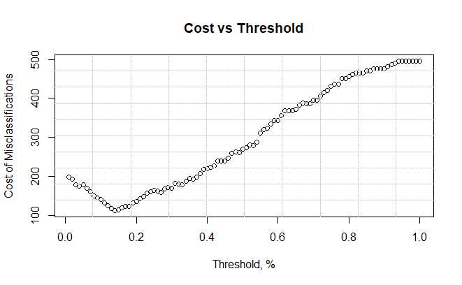

```r
#initialize list
cost <- vector(mode = "list")
for (i in 1:100){
  preds_rounded <- as.integer(preds > i/100 )
  cm_matrix <- as.matrix(table(test$V21, preds_rounded))

  #Ensuring NO out of bounds issues while looping
  if(nrow(cm_matrix)==2) {fp<-cm_matrix[2,1]} else {fp=0}
  if(ncol(cm_matrix)==2){fn<-cm_matrix[1,2]} else {fn=0}

  cost<-c(cost, fn*1+fp*5)
  }

#Plots ov Total cost vs % thresholds
plot(x=seq(0.01,1,by=0.01),
     y=cost,
     xlab="Threshold, %",
     ylab="Cost of Misclassifications",
     main="Cost vs Threshold")
grid (10,10,lty=6)
```

```r
print(sprintf("optimal threshold: %0.3f", min.threshold))
```

```
[1] "optimal threshold: 0.140"
```

Finally obtain the minimum cost and its corresponding optimal threshold, which is 0.140.